# Task 1: Visualizing Amphibian Counts in the Sierra Nevadas

Nick McManus

2023-01-25

```r
knitr::opts_chunk$set(echo = TRUE, message = FALSE, warning = FALSE)
library(tidyverse) #always
library(readxl)    #use to import .xlsx data
library(lubridate) #dates
library(calecopal) #color themes
library(cowplot)   #merging graphs
```

## Introduction

The amphibian data visualized in this task comes from the Sierra Lakes Inventory Project (SLIP). This project ran from 1995-2002 and surveyed aquatic communities — including amphibians, reptiles, fish, macroinvertebrates, and zooplankton — in over 8,000 water bodies in the southern Sierra Nevada. In this task, we will explore the abundance of just one species: the mountain yellow-legged frog (*Rana muscosa*). First, we determine the number of *R. muscosa* observed in the Sierras by life stage and year. Next, we determine which lakes contained the greatest number of observations throughout the project. These data will are finally presented in a composite figure.

**Source:** Knapp, R.A., C. Pavelka, E.E. Hegeman, and T.C. Smith. 2020. The Sierra Lakes Inventory Project: Non-Native fish and community composition of lakes and ponds in the Sierra Nevada, California ver 2. Environmental Data Initiative. https://doi.org/10.6073/pasta/d835832d7fd00d9e4466e44eea87fab3

## Data wrangling

First we’ll read in the data:

```r
amphibians <- read_excel("data/sierra_amphibians.xlsx")
```

Now we’ll wrangle the data to isolate our species of interest, *Rana muscosa*. Specifically, we only want to keep observations for adult, subadult, and tadpole *R. muscosa* across the study area. Then, we group and summarize the dataset by life stage and survey year to create the first component of our figure.

```r
ramu <- amphibians %>%
  # return only R. muscosa obs
  filter(amphibian_species == "RAMU") %>%
  # remove obs for frogs in eggmass life stage
  filter(amphibian_life_stage != "EggMass") %>%
  # isolate year from survey_date and move column
  mutate(year = lubridate::year(survey_date)) %>%
  relocate(year, .before = amphibian_location) %>%
  # remove unneeded variables
  select(!c(survey_date, amphibian_species, amphibian_state, amphibian_voucher))


### 1st graph: determine counts by life stage and year
ramu_counts_year <- ramu %>%
  group_by(amphibian_life_stage, year) %>%
  summarize(count = sum(amphibian_number, na.rm = T))
```

For the second component of our figure, we remove tadpole data to focus on observations of adult and sub-adult *R. muscosa*. After grouping the data by location, we can determine which five lakes contained the greatest number of observations during the length of SLIP.

```r
### 2nd graph: determine counts by lake and return top 5
ramu_counts_lake <- ramu %>%
  # remove obs for tadpoles
  filter(amphibian_life_stage != "Tadpole") %>%
  # combine counts for adult + subadult by lake_id
  group_by(lake_id) %>%
  summarize(count = sum(amphibian_number, na.rm = T)) %>%
  # return only top 5
  slice_max(order_by = count, n = 5)  %>%
  # add "Lake" to id name, then reclass to factor
  mutate(lake_id = paste0("Lake ", lake_id)) %>%
  mutate(lake_id = as.factor(lake_id))
```

## Data visualization

Let’s create the first component of our composite figure, where we visualize the total number of *R. muscosa* counts each year across all water bodies by life stage.

```r
years_fig <- ggplot(data = ramu_counts_year, aes(x = year, y = count)) +
  # set geometry
  geom_col(aes(fill = amphibian_life_stage)) +
  # customize bar colors
  scale_fill_manual(values = cal_palette("lake")) +
  # set years on axes
  scale_x_continuous(breaks = seq(from = 1995, to = 2002, by = 1)) +
  scale_y_continuous(breaks = seq(from = 0, to = 200000, by = 50000),
                     expand = c(0, 0), limits = c(0, 190000)) +
  # set labels
  labs(x = "Year",
       y = "Count",
       fill = "Life Stage") +
  # set theme
  theme_bw() +
  theme(
    # customize axis labels
    axis.title.x = element_text(face = "bold"),
    axis.title.y = element_text(face = "bold"),
    axis.text.x = element_text(size = 8),
    axis.text.y = element_text(size = 8),
    axis.ticks = element_blank(),
    # remove vertical lines
    panel.grid.major.x = element_blank(),
    panel.grid.minor.x = element_blank(),
    # set custom position for legend
    legend.position = c(0.15, 0.85),
    legend.title = element_text(face = 'bold', size = 10))
```

Now let’s make our second component, which visualizes the total number of adult and sub-adult *R. muscosa* observed in the five lakes with greatest observed counts.

```r
lakes_fig <- ggplot(data = ramu_counts_lake,
                    aes(x = reorder(lake_id, count),
                        y = count)) +
  # set geometry and bar color
  geom_col(width = 0.8, fill = '#7AC9B7', color = '#6CA184')+
  # axis label
  labs(x = "Lake ID") +
  # customize y axis ticks
  scale_y_continuous(breaks = seq(from = 0, to = 3000, by = 500),
                     expand = c(0, 0), limits = c(0,2750)) +
  # add values to columns
  geom_text(aes(label = count), nudge_y = 65, size = 2.8) +
  # set theme
  theme_bw() +
  theme(
    # customize axis labels
    axis.title.x = element_text(face = "bold"),
    axis.title.y = element_blank(),
    # make axis tick labels smaller
    axis.text.x = element_text(size = 8),
    axis.text.y = element_text(size = 8),
    axis.ticks = element_blank(),
    # remove v lines
    panel.grid.major.x = element_blank(),
    panel.grid.minor.x = element_blank(),
    # remove minor h lines
    panel.grid.minor.y = element_blank())
```

Finally, we’ll combine the graphs to form our finalized figure.

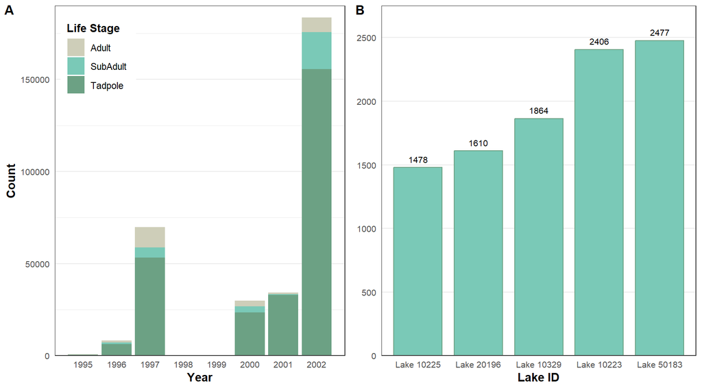

```r
plot_grid(years_fig, lakes_fig,
          align = 'h',
          greedy = TRUE,
          labels = c('A', 'B'),
          label_size = 12,
          hjust = -0.5,
          vjust = 1.5)
```

**Figure 1.** The number of *R. muscosa* observations between 1995-2002 in the southern Sierra Nevadas. Figure 1A (left) displays counts by year and life stage. Counts for the three life stages – tadpole, sub-adult, and adult – are differentiated within a single bar by dark, mid, and light green colors, respectively. No observations for *R. muscosa* were recorded for the years 1998-1999. Figure 1B (right) displays the five lakes with the greatest number of combined adult and sub-adult *R. muscosa* observations across all years. Count numbers are displayed above each bar.